# Homework #3

Robert Hereth

10/8/2021

The following homework assignment focuses on the uses of bootstrapping and how it creates confidence intervals. We also discover some cases where bootstrapping can lead to useless information.

# Problem 1

## Problem Statement

Using the `ames` dataset, bootstrap a 95% confidence interval on the mean and median of the price per square foot of houses in Ames, Iowa from 2006 to 2010. Show images of the sampling distributions, along with confidence markers, and explain when you would use the mean over the median and vice versa.

## Solution

In order to bootstrap this sample, we iterate through a loop where we grab the dataset, select rows of data at random, and create our sample statistic from them. The `mean` and `median` sets were both created in the same bootstrapping loop to ensure that the data and samples were consistent across the two values.

```r
library(tidyverse)
library(openintro)
df <- ames %>%
  select(area, price)
means <- c()
medians <- c()
n <- 2000
for(j in 1:n){
  rows <- sample(1:nrow(df), size=nrow(df), replace=T)
  dfBoot <- df[rows,]
  means[j] <- mean(dfBoot$price)/mean(dfBoot$area)
  medians[j] <- median(dfBoot$price)/median(dfBoot$area)
}
```

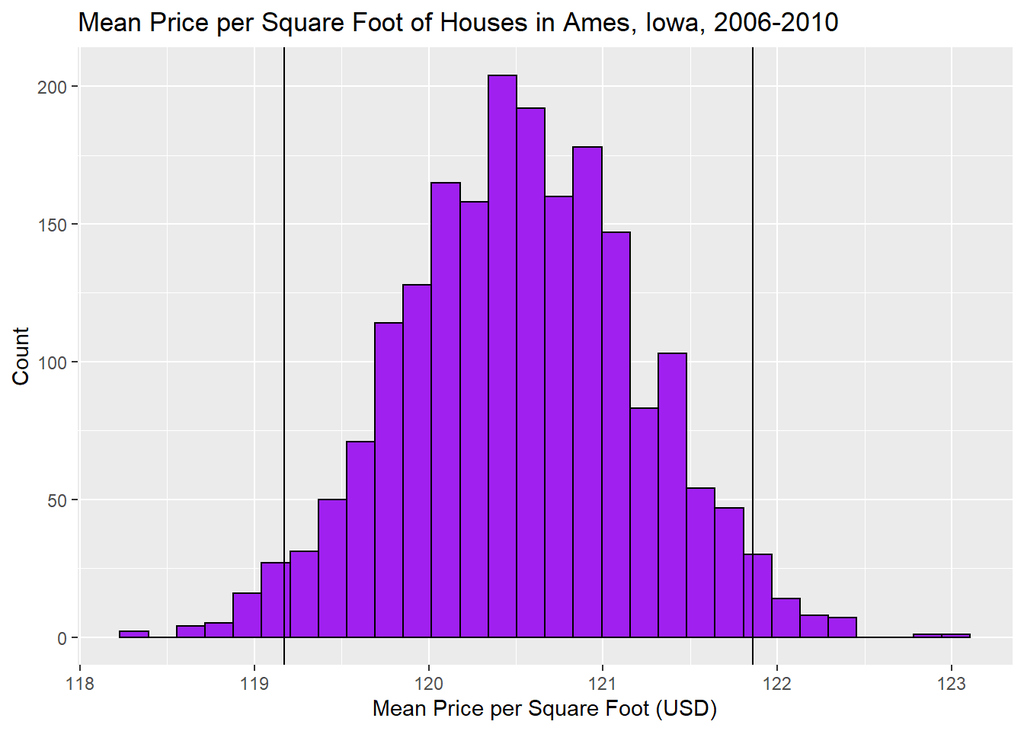

```r
library(tidyverse)
library(openintro)
lMean <- quantile(means,.025)
uMean <- quantile(means, .975)
ggplot() + geom_histogram(aes(means), fill="purple", color="black") +
  geom_vline(xintercept=lMean) + geom_vline(xintercept=uMean) +
  labs(title="Mean Price per Square Foot of Houses in Ames, Iowa, 2006-2010",
       y="Count",x="Mean Price per Square Foot (USD)")
```

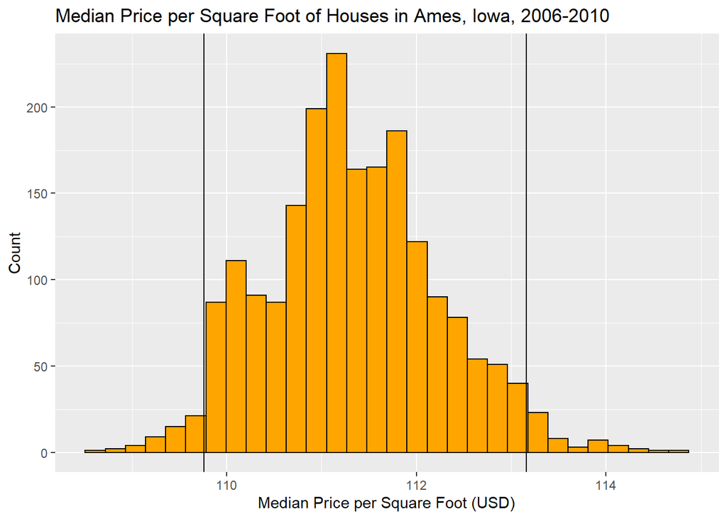

```r
library(tidyverse)
library(openintro)
lMed <- quantile(medians, .025)
uMed <- quantile(medians, .975)
ggplot() + geom_histogram(aes(medians), fill="orange", color="black") +
  geom_vline(xintercept=lMed) + geom_vline(xintercept=uMed) +
  labs(title="Median Price per Square Foot of Houses in Ames, Iowa, 2006-2010",
       y="Count",x="Median Price per Square Foot (USD)")
```

As seen above, the bounds for the mean are (119.1697391, 121.85887), while the bounds for the median are (109.7635135, 113.161739). The median is often used as the measuring statistic when the dataset has far and variably spread outliers, whereas the mean is more useful when the outliers of the dataset are closer to the central data.

# Problem 2

## Problem Statement

Construct multiple 95% confidence intervals, using different methods, around the mean price of houses in Ames, Iowa from 2006 to 2010 using the data provided in the `ames` dataset. In addition, construct a histogram that displays the distribution of prices.

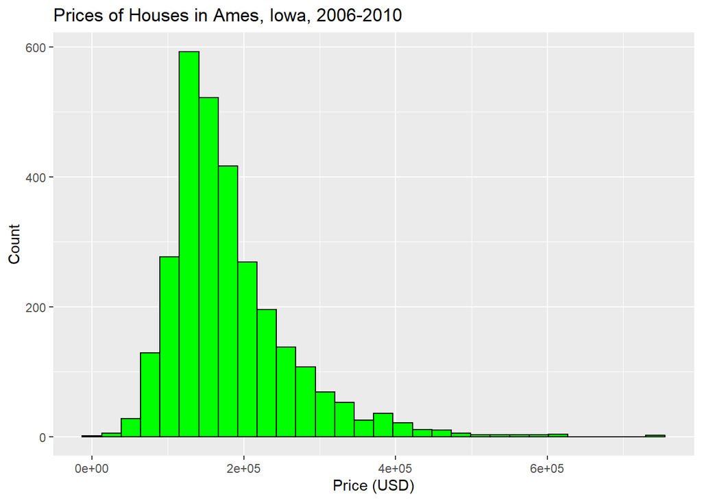

```r
library(tidyverse)
library(openintro)
df <- ames %>%
  select(price)
ggplot(df, aes(price)) + geom_histogram(fill="green", color="black") +
  labs(title="Prices of Houses in Ames, Iowa, 2006-2010",
       x="Price (USD)",y="Count")
```

## Part A

```r
library(tidyverse)
library(openintro)
df <- ames %>%
  select(price)
a_M <- mean(df$price, na.rm=T)
a_S <- sd(df$price, na.rm=T)
a_n <- nrow(df)
a_se <- a_S/sqrt(a_n)
a_crit <- qt(0.975, a_n-1)
a_moe <- a_crit*a_se
a_low <- a_M-a_moe
a_upper <- a_M+a_moe
```

The first method for creating the confidence interval is the classical method. Through this method, we find the mean, standard deviation, and standard error in order to construct our standard error and margin of error. Once we have the margin of error, we add and subtract it from the mean in order to create our bounds. Through this method, our bounds for the 95% confidence interval on the mean price is (1.7790226^{5}, 1.8368986^{5}).

## Part B

```r
library(tidyverse)
library(openintro)
df <- ames %>%
  select(price) %>%
  mutate(logPrice = log10(price))
#ggplot(df, aes(logPrice)) + geom_histogram()
b_M <- mean(df$logPrice, na.rm=T)
b_S <- sd(df$logPrice, na.rm=T)
b_n <- nrow(df)
b_se <- b_S/sqrt(b_n)
b_crit <- qt(0.975, b_n-1)
b_moe <- b_crit*b_se
b_low <- b_M-b_moe
b_upper <- b_M+b_moe
b_expLow <- 10**b_low
b_expUpper <- 10**b_upper
```

The second method for creating a confidence interval is through preforming the same classical method from Part A, but we do the measurements with the base 10 logarithmic prices and convert them back to the actual prices at the end. Through this method, the bounds of our confidence interval are (1.6376772^{5}, 1.6867567^{5}).

## Part C

```r
library(tidyverse)
library(openintro)
df <- ames %>%
  select(price)
meanPrices <- c()
n <- 2000
for(j in 1:n){
  rows <- sample(1:nrow(df), size=nrow(df), replace=T)
  dfBoot <- df[rows,]
  meanPrices[j] <- mean(dfBoot$price)
}
mpLow <- quantile(meanPrices, .025)
mpUpper <- quantile(meanPrices, .975)
```

The last method we have for creating our confidence interval are to bootstrap the sample and find the quantile cutoffs for our bounds, being 2.5% and 97.5%. Though this method, the bounds of our confidence interval are (1.7807403^{5}, 1.8372078^{5}).

## Part D

The final part of this question focuses on discussing which confidence interval can be seen as the “true” confidence for the `price` data. Personally, I believe that the bootstrapping interval gives us the best approximation due to the way the values are calculated. By sampling our data with replacement, we have a nearly infinite number of datasets that we can sample from. This allows us to get a wide range of values that are all plausible within the confides of this scenario. With our larger sampling base, we are able to get a more accurate depiction of the average price.

# Problem 3

## Problem Statement

Using the `Violations` dataset from `mdsr`, find the 95% confidence interval of the range, IQR, and standard deviation of restaurant health code scores within Manhattan. In addition, create a plot that displays the score distribution of the trimmed dataset.

## Solution

The plot below depicts the distribution of health scores within Manhattan restaurants and the heavily skewed nature of the data.

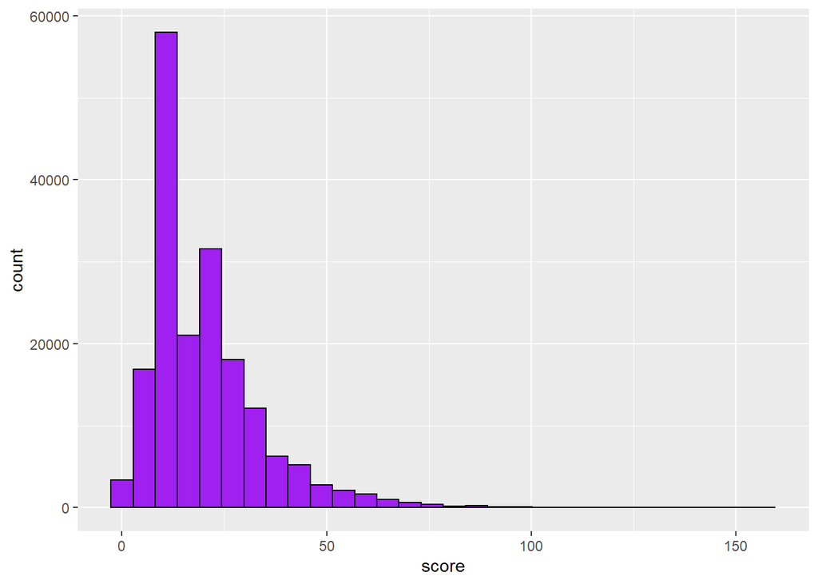

```r
library(tidyverse)
library(mdsr)
vio <- Violations %>%
  filter(boro=="MANHATTAN") %>%
  select(score) %>%
  drop_na()
ggplot(vio, aes(score))+geom_histogram(fill="purple", color="black")
```

The remaining code uses bootstrapping to create samples of the range, IQR, and standard deviation of these scores. We then create our confidence interval bounds through the use of the `quantile` command with our percentile cutoffs.

```r
library(tidyverse)
library(mdsr)
Ranges <- c()
IQRs <- c()
SDs <- c()
n <- 1000
for(j in 1:n){
  rows <- sample(1:nrow(vio), size=nrow(vio), replace=T)
  boot <-vio[rows,]
  Ranges[j] <- max(boot$score)-min(boot$score)
  IQRs[j] <- quantile(boot$score, .75)-quantile(boot$score, .25)
  SDs[j] <- sd(boot$score)
}
```

```r
library(tidyverse)
library(mdsr)
library(knitr)
lRange <- quantile(Ranges, .025)
uRange <- quantile(Ranges, .975)
lIQR <- quantile(IQRs, .025)
uIQR <- quantile(IQRs, .975)
lSD <- quantile(SDs, .025)
uSD <- quantile(SDs, .975)
table <- matrix(c(lRange, lIQR, lSD, uRange, uIQR, uSD), ncol=3, byrow=T)
colnames(table) <- c("Range", "IQR", "Standard Deviation")
rownames(table) <- c("Lower Bound", "Upper Bound")
table <- as.table(table)
(kable(table, caption="Table of Values"))
```

Table of Values

|  | Range | IQR | Standard Deviation |
| --- | --- | --- | --- |
| Lower Bound | 157 | 15 | 13.44742 |
| Upper Bound | 157 | 15 | 13.60976 |

The table above displays the values we found for all of the measurements. As you can see, the range and IQR bounds are the same. Upon first look, these measurements seem incorrect. In reality, they make complete sense. If we sample from the same dataset over and over, the range and IQR will be the same, as they pull from the same data. The standard deviation changes though, due to the always different interiors of our samples. Because the IQR and range are focused on the distance between all the data, we get the same values as long as the samples each have the highest and lowest points. Due to the highly skewed nature of this data, we tend to get values that are heavily favoring lower scores and loosely fitting the higher scores.